# 2025-26 Q1 Data Report

Molly Wilson

2025-09-15

```r
# quarterly settings

q_label <- "Q1 2025-26"
q_start <- "2025-07-01"
q_end <- "2025-09-30"

# biannual settings
b_start <- "2025-07-01"
b_end <- "2025-12-31"
```

# Nurseries

## Genebank monitoring

- APAL53 (Cades) and APAL18 (York) had more frags at end of Q than beginning, with nothing recorded as having been added…
- Survivorship (number of frags at end vs. beginning + additions) currently includes diseased frags in total frag number at both beginning and end. Does this make sense?
- Rates of infection, bleaching, etc. are currently calculated as the mean of % incidence at each monitoring date across the quarter. Eventually I need to incorporate longer-term performance into genotype tracking sheet.

```r
# import genotype tracking - genebank data

gb_mon <- read_excel(here("restoration_monitoring", "data_raw", "Genotype tracking.xlsx"), sheet = "genebank monitoring") %>%
  clean_names() %>%
  mutate(date = ymd(as.character(date))) %>%
  filter(date >= as.Date(q_start) & date <= as.Date(q_end)) %>%
  mutate(species = substr(genotype, 1, 4),
         across(starts_with("n_"), ~ replace_na(.x, 0)),
         n_diseased = n_diseased_pruned + n_diseased_removed, # currently not distinguishing, this matches col names for merging with nursery_frags
         n_tot = n_healthy + n_bleached + n_pale + n_diseased + n_other) %>%
  select(-n_diseased_pruned, -n_diseased_removed)

gb_mon_last <- gb_mon %>%
  group_by(nursery) %>%
  slice_max(date, n = 1) %>%
  ungroup()

# determine rates of survival, infection, bleaching, and paling by genotype and by nursery

gb_perf <- gb_mon %>%
  group_by(nursery, genotype) %>%
  arrange(date) %>%
  summarise(p_survival = last(n_tot) / (first(n_tot) + sum(n_added)), # account for any fragments added during Q
            p_diseased = mean(n_diseased / n_tot, na.rm = TRUE),
            p_bleached = mean(n_bleached / n_tot, na.rm = TRUE),
            p_pale = mean(n_pale / n_tot, na.rm = TRUE),
            .groups = "drop")

datatable(gb_perf,
          options = list(pageLength = 15),
          rownames = FALSE)
```

| nursery | genotype | p_survival | p_diseased | p_bleached | p_pale |
| --- | --- | --- | --- | --- | --- |
| Cades | ACER07 | 1 | 0 | 0 | 0 |
| Cades | ACER12 | 1 | 0 | 0 | 0 |
| Cades | APAL12 | 1 | 0 | 0 | 0 |
| Cades | APAL13 | 1 | 0 | 0 | 0 |
| Cades | APAL25 | 1 | 0 | 0 | 0 |
| Cades | APAL48 | 1 | 0 | 0 | 0 |
| Cades | APAL49 | 1 | 0 | 0 | 0 |
| Cades | APAL50 | 1 | 0 | 0 | 0 |
| Cades | APAL51 | 1 | 0 | 0 | 0.5 |
| Cades | APAL52 | 1 | 0 | 0 | 0.1666666666666667 |

[output cut: 50 more lines]

## Nursery stats

- Missing frag counts from TPB shallow table - just included genotypes there for species/genotype counts

```r
nursery_mon <- read_excel(here("restoration_monitoring", "data_raw", "Genotype tracking.xlsx"), sheet = "nursery monitoring") %>%
  clean_names() %>%
  mutate(date = ymd(as.character(date)),
         nursery = if_else(nursery == "TPB", "Ten Pound Bay", nursery)) %>%
  filter(date >= ymd(q_start) & date <= ymd(q_end)) %>%
  mutate(species = substr(genotype, 1, 4),
         across(starts_with("n_"), ~ replace_na(.x, 0)),
         n_tot = n_healthy + n_bleached + n_pale + n_diseased + n_other)

nurs_mon_last <- nursery_mon %>%
  group_by(nursery) %>%
  slice_max(date, n = 1) %>% # keep row(s) with max date per nursery, assumes all monitoring per nursery done in one day
  ungroup()

nurs_gb_mon_last <- bind_rows(nurs_mon_last, gb_mon_last) %>%
  select(date, nursery, location, species, genotype, starts_with("n_"), -n_added)
```

### By nursery

```r
frags_nursery <- nurs_gb_mon_last %>%
  group_by(nursery) %>%
  summarize(n_tot = sum(n_tot),
            n_healthy = sum(n_healthy),
            n_bleached = sum(n_bleached),
            n_pale = sum(n_pale),
            n_diseased = sum(n_diseased)) %>%
  adorn_totals("row") %>%
  mutate(p_healthy = percent(n_healthy / n_tot, accuracy = 0.1),
         p_heatstress = percent((n_bleached + n_pale) / n_tot, accuracy = 0.1),
         p_diseased = percent(n_diseased / n_tot, accuracy = 0.1)) %>%
  left_join(nurs_gb_mon_last %>%
              select(nursery, species) %>%
              distinct() %>%
              group_by(nursery) %>%
              summarize(n_spp = n())) %>%
  left_join(nurs_gb_mon_last %>%
              select(nursery, genotype) %>%
              distinct() %>%
              filter(!str_detect(genotype, "XX")) %>% # don't want unknown genotypes to double count
              group_by(nursery) %>%
              summarize(n_genotypes = n())) %>%
  select(nursery, n_spp, n_genotypes, n_frags = n_tot, p_healthy, p_heatstress, p_diseased)

kable(frags_nursery)
```

| nursery | n_spp | n_genotypes | n_frags | p_healthy | p_heatstress | p_diseased |
| --- | --- | --- | --- | --- | --- | --- |
| Cades | 7 | 26 | 423 | 98.6% | 0.9% | 0.0% |
| Jumby | 11 | 27 | 1250 | 100.0% | 0.0% | 0.0% |
| Ten Pound Bay | 12 | 36 | 440 | 100.0% | 0.0% | 0.0% |
| York | 3 | 45 | 1364 | 99.9% | 0.1% | 0.0% |
| Total | NA | NA | 3477 | 99.8% | 0.1% | 0.0% |

### By species

```r
frags_spp <- nurs_gb_mon_last %>%
  select(species, genotype) %>%
  distinct() %>%
  filter(!str_detect(genotype, "XX")) %>% # don't want unknown genotypes to double count
  group_by(species) %>%
  summarize(n_genotypes = n()) %>%
  left_join(nurs_gb_mon_last %>%
              group_by(species) %>%
              summarize(n_tot = sum(n_tot),
                        n_healthy = sum(n_healthy),
                        n_bleached = sum(n_bleached),
                        n_pale = sum(n_pale),
                        n_diseased = sum(n_diseased))) %>%
  adorn_totals("row") %>%
  mutate(p_healthy = percent(n_healthy / n_tot, accuracy = 0.1),
         p_heatstress = percent((n_bleached + n_pale) / n_tot, accuracy = 0.1),
         p_diseased = percent(n_diseased / n_tot, accuracy = 0.1)) %>%
  select(species, n_genotypes, n_frags = n_tot, p_healthy, p_heatstress, p_diseased)

datatable(frags_spp,
          options = list(pageLength = 15),
          rownames = FALSE)
```

| species | n_genotypes | n_frags | p_healthy | p_heatstress | p_diseased |
| --- | --- | --- | --- | --- | --- |
| ACER | 2 | 214 | 99.5% | 0.5% | 0.0% |
| APAL | 41 | 1520 | 99.7% | 0.1% | 0.0% |
| APRO | 10 | 709 | 99.7% | 0.3% | 0.0% |
| CNAT | 1 | 36 | 100.0% | 0.0% | 0.0% |
| DCYL | 1 | 106 | 100.0% | 0.0% | 0.0% |
| DLAB | 7 | 240 | 100.0% | 0.0% | 0.0% |
| MCAV | 1 | 23 | 100.0% | 0.0% | 0.0% |
| OANN | 6 | 236 | 100.0% | 0.0% | 0.0% |
| OFAV | 5 | 264 | 100.0% | 0.0% | 0.0% |
| OFRA | 1 | 23 | 100.0% | 0.0% | 0.0% |

[output cut: 5 more lines]

### By genotype

*See genotype tracking for consolidated summary*

```r
frags_genotype <- nurs_gb_mon_last %>%
  group_by(genotype) %>%
  summarize(n_tot = sum(n_tot)) %>%
  select(genotype, n_frags = n_tot)
```

### By structure

- Could eventually add structure type, but not sure how to automate this based on current nursery map formatting

```r
frags_structure <- nurs_gb_mon_last %>%
  group_by(nursery, location) %>%
  summarize(n_tot = sum(n_tot)) %>%
  select(nursery, location, n_frags = n_tot)

datatable(frags_structure,
          options = list(pageLength = 10),
          rownames = FALSE)
```

| nursery | location | n_frags |
| --- | --- | --- |
| Cades | A1 | 42 |
| Cades | A2 | 57 |
| Cades | A3 | 70 |
| Cades | A4 | 145 |
| Cades | B1 | 18 |
| Cades | B2 | 55 |
| Cades | B3 | 36 |
| Jumby | A1 | 207 |
| Jumby | A2 | 186 |
| Jumby | A3 | 211 |

[output cut: 52 more lines]

## Nursery locations

### Map locations

```r
letter_names <- function(nms) LETTERS[seq_along(nms)]

map_york <- read_excel(here("restoration_monitoring", "data_raw", "Nursery map.xlsx"), sheet = "York",
                   range = "A1:F9", col_names = FALSE, .name_repair = letter_names) %>%
  mutate(row = row_number()) %>%
  pivot_longer(cols = -row,
               names_to = "col",
               values_to = "genotype",
               values_drop_na = TRUE) %>%
  unite(location, col, row, sep = "", remove = TRUE, na.rm = TRUE) %>%
  mutate(nursery = "York")

map_tpb <- read_excel(here("restoration_monitoring", "data_raw", "Nursery map.xlsx"), sheet = "TPB",
                   range = "A1:B10", col_names = FALSE, .name_repair = letter_names) %>%
  mutate(row = row_number()) %>%
  pivot_longer(cols = -row,
               names_to = "col",
               values_to = "genotype",
               values_drop_na = TRUE) %>%
  bind_rows(read_excel(here("restoration_monitoring", "data_raw", "Nursery map.xlsx"), sheet = "TPB",
                       range = "A13:H20", col_names = FALSE) %>%
              pivot_longer(
                cols = everything(),
                names_to = NULL,
                values_to = "genotype",
                values_drop_na = TRUE) %>%
              distinct() %>%
              mutate(col = "ST")
  ) %>%
  unite(location, col, row, sep = "", remove = TRUE, na.rm = TRUE) %>%
  mutate(nursery = "Ten Pound Bay")


map_cades <- read_excel(here("restoration_monitoring", "data_raw", "Nursery map.xlsx"), sheet = "Cades",
                   range = "A1:B10", col_names = FALSE, .name_repair = letter_names) %>%
  mutate(row = row_number()) %>%
  pivot_longer(cols = -row,
               names_to = "col",
               values_to = "genotype",
               values_drop_na = TRUE) %>%
  unite(location, col, row, sep = "", remove = TRUE, na.rm = TRUE) %>%
  mutate(nursery = "Cades")

map_jumby <- read_excel(here("restoration_monitoring", "data_raw", "Nursery map.xlsx"), sheet = "Jumby",
                   range = "A1:C8", col_names = FALSE, .name_repair = letter_names) %>%
  pivot_longer(cols = everything(),
               names_to = NULL,
               values_to = "genotype",
               values_drop_na = TRUE) %>%
  mutate(
    location = str_sub(genotype, 1, 2),
    genotype = str_sub(genotype, 4),
    nursery = "Jumby")

nursery_maps <- rbind(map_york, map_tpb, map_cades, map_jumby) %>%
  mutate(genotype = strsplit(as.character(genotype), " / ")) %>%
  unnest(genotype) %>%
  filter(!str_detect(genotype, "GB|XX")) %>% # removing genebanks and unknown genotypes
  mutate(geno_check = nchar(genotype) == 6)
# this does not include genebanks yet
```

### Monitoring locations

```r
nursery_locations <- nurs_mon_last %>%
              select(genotype, nursery, location) %>%
              group_by(genotype, nursery) %>%
              summarise(location = paste(location, collapse=", ")) %>%
              pivot_wider(names_from = nursery, values_from = location) %>%
              rename(york_locations = "York",
                     tpb_locations = "Ten Pound Bay",
                     cades_locations = "Cades",
                     jumby_locations = "Jumby")

gb_locations <- gb_mon_last %>%
  unite("location", nursery, location) %>%
  group_by(genotype) %>%
  summarise(gb_locations = paste(location, collapse=", "))
```

### Consistency check

*Inconsistencies in location records between nursery maps and nursery monitoring*

```r
diff_nmap <- anti_join(nursery_maps %>% select(nursery, location, genotype),
                       nurs_mon_last %>% select(nursery, location, genotype),
                       by = c("nursery", "location", "genotype"))

diff_nmon <- anti_join(nurs_mon_last %>% select(nursery, location, genotype),
                       nursery_maps %>% select(nursery, location, genotype),
                       by = c("nursery", "location", "genotype"))

diff_locations <- bind_rows(
  mutate(diff_nmap, source = "nursery maps"),
  mutate(diff_nmon, source = "nursery monitoring"))

kable(diff_locations)
```

| nursery | location | genotype | source |
| --- | --- | --- | --- |
| York | C1 | APAL73 | nursery maps |
| York | D7 | APAL51 | nursery maps |
| Ten Pound Bay | A2 | OFAV06 | nursery maps |
| Ten Pound Bay | A2 | DCYL03 | nursery maps |
| Ten Pound Bay | A2 | PSTR04 | nursery maps |
| York | C5 | APAL10 | nursery monitoring |
| York | C6 | APAL51 | nursery monitoring |
| York | D7 | APAL25 | nursery monitoring |

# Collections

- Merge DCYL02 and DCYL03?

```r
collection <- read_excel(here("restoration_monitoring", "data_raw", "Genotype tracking.xlsx"), sheet = "collection") %>%
  clean_names() %>%
  mutate(across(everything(),
                ~ ifelse(grepl("^(na|n/a)$", ., ignore.case = TRUE), NA, .)),
         collection_date = as.Date(as.numeric(date), origin = "1899-12-30"),
         site = str_to_title(site),
         species = substr(genotype, 1, 4)) %>%
  rename(collection_site = site,
         collection_lat = lat,
         collection_lon = lon) %>%
  select(genotype, species, collection_date, collection_site, collection_lat, collection_lon) %>%
  group_by(genotype) %>%
  slice_min(collection_date, n = 1)
```

## By species

```r
collection_spp <- collection %>%
  group_by(species) %>%
  summarize(colonies = n()) %>%
  adorn_totals("row")

datatable(collection_spp,
          rownames = FALSE)
```

| species | colonies |
| --- | --- |
| ACER | 12 |
| APAL | 76 |
| APRO | 16 |
| CNAT | 4 |
| DCYL | 2 |
| DLAB | 7 |
| MCAV | 2 |
| OANN | 15 |
| OFAV | 13 |
| OFRA | 1 |

[output cut: 5 more lines]

## By site

```r
collection_sites <-
  collection %>%
  group_by(collection_site) %>%
  summarize(colonies = n()) %>%
  adorn_totals("row")

datatable(collection_sites,
          rownames = FALSE)
```

| collection_site | colonies |
| --- | --- |
| Bird Island West | 7 |
| Cades Reef | 23 |
| Cervi Heaven | 1 |
| Devil's Bridge | 1 |
| Exchange Bay | 1 |
| Friar's Head | 1 |
| Great Bird | 12 |
| Hells Gate | 19 |
| Indian Creek | 3 |
| Little Bird Channel | 6 |

[output cut: 19 more lines]

# Outplants

## Outplant numbers

Currently spiders at TPB are considered outplants, while spiders at Jumby are considered nursery frags. Keep as is?

```r
outplants <- read_excel(here("restoration_monitoring", "data_raw", "Genotype tracking.xlsx"), sheet = "outplants") %>%
  clean_names() %>%
  mutate(genotype = substr(id, 1, 6),
         species = substr(id, 1, 4)) %>%
  filter(!is.na(date)) %>%
  select(date, site, species, genotype, id, n_frags, n_colonies)
```

### By genotype

```r
outplant_genotypes <- outplants %>%
  filter(year(date) >= 2024) %>% # not including outplants prior to bleaching
  group_by(genotype, site) %>%
  summarize(n_frags = sum(n_frags)) %>%
  pivot_wider(names_from = site, values_from = n_frags) %>%
  mutate(across(everything(), ~ replace_na(., 0))) %>%
  mutate(total = rowSums(across(where(is.numeric)), na.rm = TRUE)) %>%
  adorn_totals("row")

datatable(outplant_genotypes,
          rownames = FALSE)
```

| genotype | Ten Pound Bay | Spithead | Cades | Cades Nursery | total |
| --- | --- | --- | --- | --- | --- |
| ACER07 | 23 | 0 | 0 | 0 | 23 |
| ACER12 | 0 | 6 | 0 | 0 | 6 |
| APAL10 | 0 | 73 | 0 | 0 | 73 |
| APAL11 | 0 | 9 | 0 | 0 | 9 |
| APAL13 | 0 | 92 | 0 | 0 | 92 |
| APAL15 | 0 | 9 | 0 | 0 | 9 |
| APAL25 | 0 | 30 | 0 | 0 | 30 |
| APAL33 | 0 | 9 | 0 | 0 | 9 |
| APAL46 | 0 | 9 | 0 | 0 | 9 |
| APAL48 | 0 | 9 | 0 | 0 | 9 |

[output cut: 52 more lines]

## Outplant monitoring

- Need to pull n_planted data directly from outplant data, to avoid omitting outplants that died previously and are no longer monitored. But how to deal with those missing ID numbers?
- Eventually test for statistical drivers of performance (site vs genotype)

```r
outplant_monitoring <- read_excel(here("restoration_monitoring", "data_raw", "genotype tracking.xlsx"), sheet = "outplant monitoring") %>%
  clean_names() %>%
  filter(!is.na(n_healthy) & # filtering out any genotypes with missing data
          date_monitored >= as.Date(b_start) &
          date_monitored <= as.Date(b_end)) %>%
  mutate(genotype = substr(id, 1, 6),
         species = substr(id, 1, 4),
         n_planted = as.numeric(n_planted),
         date_monitored = ymd(date_monitored),
         date_planted = ymd(date_planted))
```

### By site

```r
outplant_perf_site <- outplant_monitoring %>%
  group_by(site) %>%
  summarize(n_planted = sum(n_planted),
            n_healthy = sum(n_healthy)) %>%
  adorn_totals("row") %>%
  mutate(survival = n_healthy/n_planted)

datatable(outplant_perf_site,
          rownames = FALSE)
```

| site | n_planted | n_healthy | survival |
| --- | --- | --- | --- |
| Cades Nursery | 464 | 351 | 0.7564655172413793 |
| Cades Outer Reef | 27 | 27 | 1 |
| Spithead | 182 | 168 | 0.9230769230769231 |
| Total | 673 | 546 | 0.8112927191679049 |

### By species

```r
outplant_perf_spp <- outplant_monitoring %>%
  group_by(species) %>%
  summarize(n_planted = sum(n_planted),
            n_healthy = sum(n_healthy)) %>%
  adorn_totals("row") %>%
  mutate(survival = n_healthy/n_planted)

datatable(outplant_perf_spp,
          rownames = FALSE)
```

| species | n_planted | n_healthy | survival |
| --- | --- | --- | --- |
| ACER | 5 | 5 | 1 |
| APAL | 153 | 142 | 0.9281045751633987 |
| APRO | 51 | 48 | 0.9411764705882353 |
| CNAT | 23 | 4 | 0.1739130434782609 |
| OANN | 217 | 193 | 0.8894009216589862 |
| OFAV | 122 | 78 | 0.639344262295082 |
| PSTR | 102 | 76 | 0.7450980392156863 |
| Total | 673 | 546 | 0.8112927191679049 |

### By genotype

```r
outplant_perf_genotype <- outplant_monitoring %>%
  filter(nchar(id) > 4) %>% # removing outplants with missing genotype tags
  group_by(genotype) %>%
  summarize(n_planted = sum(n_planted),
            n_healthy = sum(n_healthy)) %>%
  mutate(survival = n_healthy/n_planted) %>%
  select(genotype, n_outplanted = n_planted, n_outplants = n_healthy, outplant_survival = survival)

datatable(outplant_perf_genotype,
          rownames = FALSE)
```

| genotype | n_outplanted | n_outplants | outplant_survival |
| --- | --- | --- | --- |
| ACER12 | 5 | 5 | 1 |
| APAL13 | 3 | 3 | 1 |
| APAL15 | 3 | 3 | 1 |
| APAL25 | 6 | 6 | 1 |
| APAL33 | 9 | 9 | 1 |
| APAL46 | 9 | 7 | 0.7777777777777778 |
| APAL48 | 3 | 3 | 1 |
| APAL49 | 12 | 12 | 1 |
| APAL50 | 6 | 6 | 1 |
| APAL51 | 3 | 3 | 1 |

[output cut: 21 more lines]

# Genotype tracking

Notes:

- Need to integrate genotype-level genebank performance over time

```r
# integrate genotype location(s) (nursery map), # frags per genotype (nursery monitoring) and genotype performance into one output

genotype_tracking <- collection %>%
  full_join(nursery_locations, by = "genotype") %>%
  full_join(frags_genotype, by = "genotype") %>%
  full_join(gb_locations, by = "genotype") %>%
  full_join(outplant_perf_genotype, by = "genotype") %>%
  mutate(updated = Sys.Date(),
         across(contains("_locations"), ~replace_na(.,"")),
         across(starts_with("n_"), ~replace_na(.,0)),
         active = if_else(if_all(contains("_locations"), ~ . == "" | is.na(.)),
                           "N", "Y"), # genotypes with frags in nurseries
         productive = if_else(if_all(contains("locations") & -all_of("gb_locations"),  ~ . == "" | is.na(.)),
                              "N", "Y")) %>% # genotypes with frags in nurseries other than genebanks
  arrange(genotype) %>%
  select(updated, genotype, active, productive, collection_date, collection_site, collection_lat, collection_lon, york_locations, tpb_locations, cades_locations, jumby_locations, gb_locations, n_frags, n_outplanted, n_outplants, outplant_survival)

datatable(genotype_tracking,
          options = list(pageLength = 20),
          rownames = FALSE)
```

| updated | genotype | active | productive | collection_date | collection_site | collection_lat | collection_lon | york_locations | tpb_locations | cades_locations | jumby_locations | gb_locations | n_frags | n_outplanted | n_outplants | outplant_survival |
| --- | --- | --- | --- | --- | --- | --- | --- | --- | --- | --- | --- | --- | --- | --- | --- | --- |
| 2025-10-06 | ACER01 | N | N | 2021-07-19 | Exchange Bay | 17.0423 | -61.68254 |  |  |  |  |  | 0 | 0 | 0 |  |
| 2025-10-06 | ACER02 | N | N | 2021-07-20 | Cervi Heaven | 17.07555 | -61.6678 |  |  |  |  |  | 0 | 0 | 0 |  |
| 2025-10-06 | ACER03 | N | N | 2021-07-21 | Little Bird Channel | 17.16702 | -61.72996 |  |  |  |  |  | 0 | 0 | 0 |  |
| 2025-10-06 | ACER04 | N | N | 2021-07-21 | Little Bird Channel | 17.16514 | -61.73107 |  |  |  |  |  | 0 | 0 | 0 |  |
| 2025-10-06 | ACER05 | N | N | 2021-07-21 | Little Bird Channel | 17.16578 | -61.73129 |  |  |  |  |  | 0 | 0 | 0 |  |
| 2025-10-06 | ACER06 | N | N | 2021-07-21 | Great Bird | 17.14907 | -61.72346 |  |  |  |  |  | 0 | 0 | 0 |  |
| 2025-10-06 | ACER07 | Y | Y | 2021-07-21 | Hells Gate | 17.13977 | -61.72128 | C8, F3 |  | B1 | E5, E7 | Cades_A2, York_E1 | 160 | 0 | 0 |  |
| 2025-10-06 | ACER08 | N | N | 2021-07-22 | Man Of War | 17.0655 | -61.66287 |  |  |  |  |  | 0 | 0 | 0 |  |
| 2025-10-06 | ACER09 | N | N | 2021-07-28 | Hells Gate | 17.14007 | -61.7209 |  |  |  |  |  | 0 | 0 | 0 |  |
| 2025-10-06 | ACER10 | N | N | 2023-03-24 | Indian Creek | 17.002958 | -61.737524 |  |  |  |  |  | 0 | 0 | 0 |  |

[output cut: 159 more lines]

```r
write.csv(genotype_tracking, here("restoration_monitoring", "data_outputs", "genotype_tracking.csv"), row.names=FALSE)
```

# Temp loggers

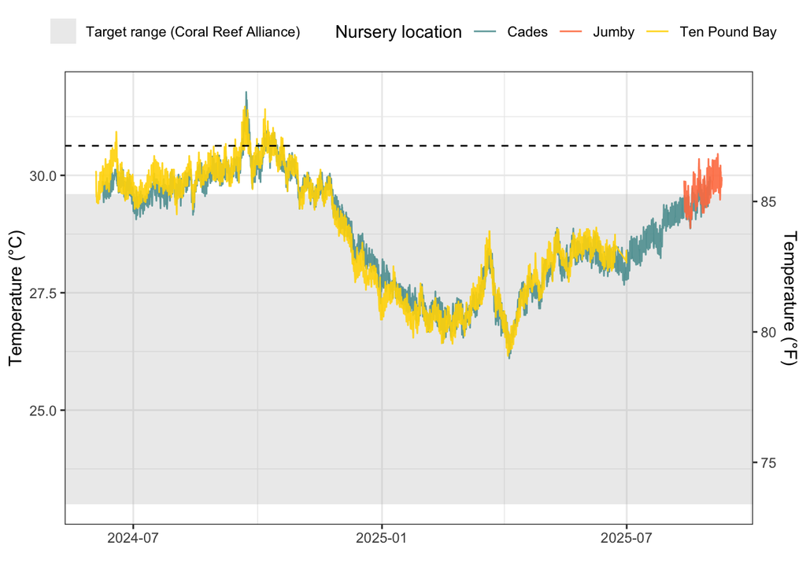

```r
cades <- read_excel(here("restoration_monitoring", "data_raw", "hobo", "Hobo logger data.xlsx"), sheet = "Cades") %>%
  clean_names() %>%
  slice(-1) %>% # remove first row
  mutate(logger = "Cades")

tpb <- read_excel(here("restoration_monitoring", "data_raw", "hobo", "Hobo logger data.xlsx"), sheet = "Ten Pound Bay") %>%
  clean_names() %>%
  slice(-1) %>%
  mutate(logger = "Ten Pound Bay")

jumby <- read_excel(here("restoration_monitoring", "data_raw", "hobo", "Hobo logger data.xlsx"), sheet = "Jumby") %>%
  clean_names() %>%
  slice(-1) %>%
  mutate(logger = "Jumby")

# create a filter to remove times during surface intervals
surf_int <- read_excel(here("restoration_monitoring", "data_raw", "hobo", "Hobo logger data.xlsx"), sheet = "Surface intervals") %>%
  clean_names() %>%
  select(-notes)

temp_data <- rbind(cades, tpb, jumby) %>%
  select(-notes) %>%
  filter(between(temp_c, 25, 35)) %>% # removing rogue outliers
  # filter out any readings taken during surface intervals
  anti_join(surf_int,
            by = join_by(
              logger == logger,
              between(date_time, surface_start, surface_end)
            )) %>%
  # drop any readings more than 2C above previous hour's reading
  arrange(logger, date_time) %>%
  group_by(logger) %>%
  mutate(temp_diff = temp_c - lag(temp_c)) %>% # create helper column
  filter(is.na(temp_diff) | temp_diff <= 2) %>%  # keep if first row or <= 2 °C jump
  ungroup() %>%
  select(-temp_diff) # drop helper column

# define references
lab_temp <- expression("Temperature ("*~degree*C*")")
ref_temp = data.frame(xmin = -Inf, xmax = Inf, ymin = 23, ymax = 29.6)
lab_ref_temp <- "Target range (Coral Reef Alliance)"
ref_temp_bleaching = 30.63
lab_ref_temp_bleaching <- "Coral bleaching threshold (NOAA)"
ylims_temp <- c(22, (max(temp_data$temp_c, na.rm = T) + 1))

# plots
ggplot() +
  geom_rect(data = ref_temp,
              aes(xmin = as.POSIXct(-Inf), xmax = as.POSIXct(Inf),
                  ymin = ymin, ymax = ymax,
                  fill = lab_ref_temp),
              alpha = 0.3) +
  scale_fill_manual(values = "gray") +
  geom_line(data = temp_data,
            aes(x = date_time, y = temp_c, group = logger, color = logger),
            alpha = 0.9) +
  scale_color_manual(values = c("cadetblue", "coral", "gold")) +
  geom_hline(yintercept = ref_temp_bleaching, linetype = 'dashed') +
  scale_y_continuous(sec.axis = sec_axis(~.*9/5+32, name = "Temperature (°F)")) +
  labs(x = "", y = "Temperature (°C)", color = "Nursery location", fill = "") +
  theme_bw() +
  theme(legend.position = "top")
```

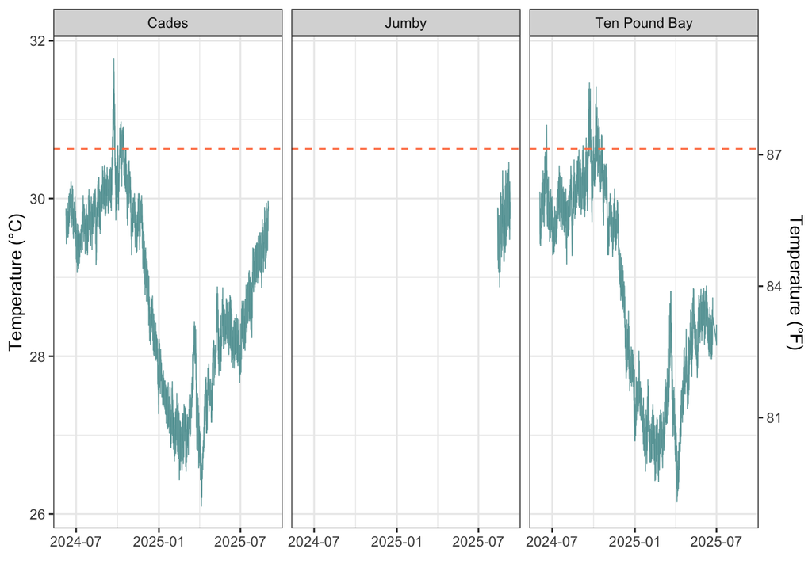

```r
ggsave(here("restoration_monitoring", "figs", "hobo_summary_25-26_Q1.png"), width = 6, height = 4)

ggplot(temp_data,
       aes(x = date_time, y = temp_c)) +
  geom_line(alpha = 0.9, size = 0.3, color = "cadetblue") +
  geom_hline(yintercept = ref_temp_bleaching, linetype = 'dashed', color = "coral") +
  scale_y_continuous(sec.axis = sec_axis(~.*9/5+32, name = "Temperature (°F)")) +
  facet_grid(. ~ logger) +
  labs(x = "", y = "Temperature (°C)", color = "Nursery") +
  theme_bw()
```

```r
ggsave(here("restoration_monitoring", "figs", "hobo_nursery_25-26_Q1.png"), width = 6, height = 4)
```